# Intro Session 2: Extending your analysis

## Task 1

**Goal**: Append the new data `gapminder-7080.csv` and and `gapminder-90plus.csv` to your existing data set.

### Reading files

Reading in the data is quick and easy with the `read.csv` function.

```r
gap_5060 <- read.csv('data/gapminder-5060.csv')
gap_7080 <- read.csv('data/gapminder-7080.csv')
gap_90plus <- read.csv('data/gapminder-90plus.csv')
```

There are a number of similarly named functions for reading files, such as `read.delim` (tab-delimited files) and `read.table` (allows you to specify the separator), and there are similar third-party solutions for Excel spreadsheets and various other formats.

Once read in, the data are stored in a data structured called a “data frame”. It’s convenient to take a quick look at the data to make sure we know what it looks like. To do so, we’ll use the `head` and `tail` functions which show the first and last lines of a data frame.

```r
head(gap_5060)
```

```
##       country continent year lifeExp      pop gdpPercap
## 1 Afghanistan      Asia 1952  28.801  8425333  779.4453
## 2 Afghanistan      Asia 1957  30.332  9240934  820.8530
## 3 Afghanistan      Asia 1962  31.997 10267083  853.1007
## 4 Afghanistan      Asia 1967  34.020 11537966  836.1971
## 5     Albania    Europe 1952  55.230  1282697 1601.0561
## 6     Albania    Europe 1957  59.280  1476505 1942.2842
```

Note that both head and tail take an optional integer argument, `n`, that specifies the number of lines to display (6 by default).

```r
tail(gap_5060, n=10)
```

```
##         country continent year lifeExp     pop gdpPercap
## 559 Yemen, Rep.      Asia 1962  35.180 6120081  825.6232
## 560 Yemen, Rep.      Asia 1967  36.984 6740785  862.4421
## 561      Zambia    Africa 1952  42.038 2672000 1147.3888
## 562      Zambia    Africa 1957  44.077 3016000 1311.9568
## 563      Zambia    Africa 1962  46.023 3421000 1452.7258
## 564      Zambia    Africa 1967  47.768 3900000 1777.0773
## 565    Zimbabwe    Africa 1952  48.451 3080907  406.8841
## 566    Zimbabwe    Africa 1957  50.469 3646340  518.7643
## 567    Zimbabwe    Africa 1962  52.358 4277736  527.2722
## 568    Zimbabwe    Africa 1967  53.995 4995432  569.7951
```

### Kable function for nice output

When working in R markdown (via knitr) we can use the `kable` function to make a prettier version of the output from `head`.

```r
library(knitr)  # loads the knitr package, so we can use kable
kable(head(gap_90plus))
```

| continent | country | year | pop | lifeExp | gdpPercap |
| --- | --- | --- | --- | --- | --- |
| Asia | Afghanistan | 1992 | 16317921 | 41.674 | 649.3414 |
| Asia | Afghanistan | 1997 | 22227415 | 41.763 | 635.3414 |
| Asia | Afghanistan | 2002 | 25268405 | 42.129 | 726.7341 |
| Asia | Afghanistan | 2007 | 31889923 | 43.828 | 974.5803 |
| Europe | Albania | 1992 | 3326498 | 71.581 | 2497.4379 |
| Europe | Albania | 1997 | 3428038 | 72.950 | 3193.0546 |

### Combining datasets

The functions `rbind` and `cbind` can be used to combine data frames. `rbind` combines rows (such as when adding now observations to a data set), `cbind` combines by columns (useful when adding new variables to a data set).

In the current context, we want to add new rows to our data set so we’ll use `rbind`. One of the really convenient things about using `rbind` rather than trying to combine the spreadsheets in a program like Excel is that `rbind` matches columns by their names rather than locations, so a simple reordering of columns in one data frame versus another is very simply dealt with.

```r
gap_combined <- rbind(gap_5060, gap_7080, gap_90plus)
```

```r
kable(head(gap_combined))
```

| country | continent | year | lifeExp | pop | gdpPercap |
| --- | --- | --- | --- | --- | --- |
| Afghanistan | Asia | 1952 | 28.801 | 8425333 | 779.4453 |
| Afghanistan | Asia | 1957 | 30.332 | 9240934 | 820.8530 |
| Afghanistan | Asia | 1962 | 31.997 | 10267083 | 853.1007 |
| Afghanistan | Asia | 1967 | 34.020 | 11537966 | 836.1971 |
| Albania | Europe | 1952 | 55.230 | 1282697 | 1601.0561 |
| Albania | Europe | 1957 | 59.280 | 1476505 | 1942.2842 |

```r
kable(tail(gap_combined))
```

|  | country | continent | year | lifeExp | pop | gdpPercap |
| --- | --- | --- | --- | --- | --- | --- |
| 1699 | Zambia | Africa | 2002 | 39.193 | 10595811 | 1071.6139 |
| 1700 | Zambia | Africa | 2007 | 42.384 | 11746035 | 1271.2116 |
| 1701 | Zimbabwe | Africa | 1992 | 60.377 | 10704340 | 693.4208 |
| 1702 | Zimbabwe | Africa | 1997 | 46.809 | 11404948 | 792.4500 |
| 1703 | Zimbabwe | Africa | 2002 | 39.989 | 11926563 | 672.0386 |
| 1704 | Zimbabwe | Africa | 2007 | 43.487 | 12311143 | 469.7093 |

## Task 2

**Goal**: Create line plots of life expectancy over time for Canada, Mexico, and the United States that run from 1952 to 2007.

- Stretch goal: In the same plot, add similar line plots for Cambodia, China, and Japan and Uganda, Egypt, and South Africa.

### Plots of life expectancy, North America

We’re going to using the `ggplot2` library to facilitate efficient figure creation, so let’s import the library.

```r
library(ggplot2)
```

Our initial goal is simply to plot life exptancy in the US, Canada, and Mexico for the years 1950 through 2007. We can do this by using the `subset` function to create a new data frame that is a a subset of the entire data set, and then drawing the data using the `geom_line()` “geom” from ggplot. “Geom” is short for “geometric object” – basically something that controls how a plot is drawn. So `geom_line()` draws our data as line plots.

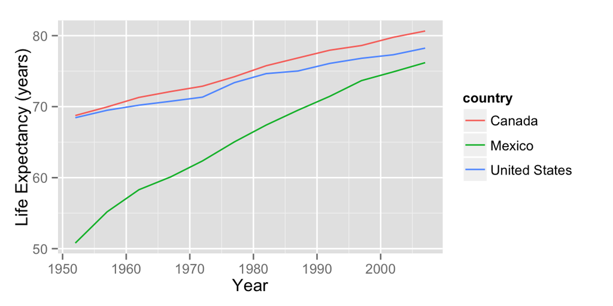

```r
gap_north_america <- subset(gap_combined, country %in% c('Canada', 'Mexico', 'United States'))

ggplot(gap_north_america, aes(x = year, y = lifeExp, color=country)) +
       geom_line() + xlab("Year") + ylab("Life Expectancy (years)")
```

### Extending life expectancy plots to include Asian and African countries

Given the example above, it’s relatively simple to extend our analysis to include Asian and African countries. As before we subset our data frame on a list of countries. One difference from the figure above is that this time we’re coloring lines by the `contintent` variable rather than country name.

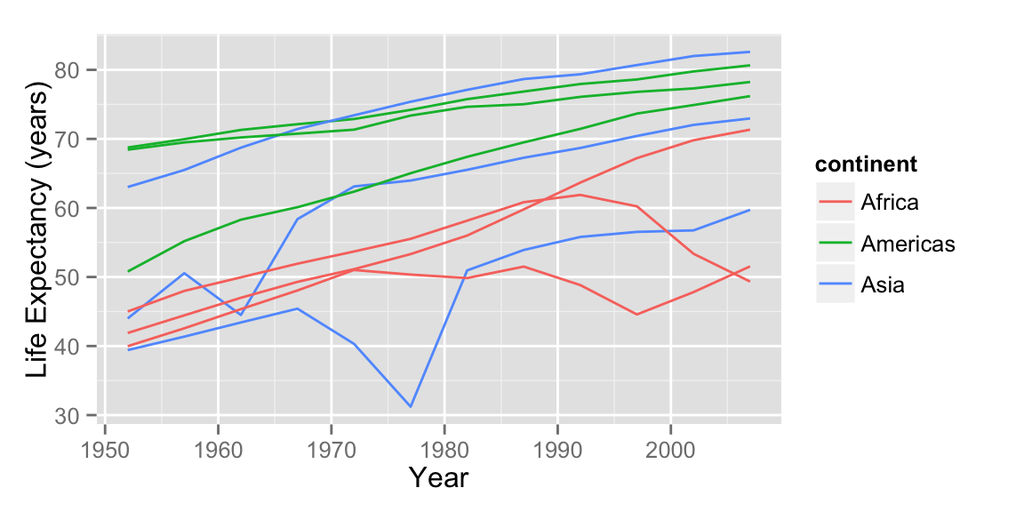

```r
country_list <- c('Canada', 'Mexico', 'United States', 'Cambodia', 'China', 'Japan', 'Egypt', 'South Africa', 'Uganda')
gap_coi <- subset(gap_combined, country %in% country_list)

ggplot(gap_coi, aes(x = year, y = lifeExp, group=country, color=continent)) +
        geom_line() + xlab("Year") + ylab("Life Expectancy (years)")
```

There are some interesting trends that are present in the figures above. Consult your knowledge of history to correlate those trends with key geopolitical events.

## Task 3

**Goal**: Create a scatter plot depictcting GDP vs. life expectancy of countries in Europe for 2007

- Stretch goal: In the same plot, add another scatter of points for Asia, Africa, and the Americas, and Oceania, coloring the countries from each region (continent) with the same color

### Scatter plots relating GDP to Life Expectancy

In Task 3, we’re no longer looking at trends over time, but rather trying to explore the relationship between two variables – GDP and life expectancy, at a fixed point in time. Thus a scatter plot is an appropriate data visualization.

The basic outline of our code is similar to the previous examples, but we now use `geom_point` instead of `geom_line` when creating our figures with ggplot. Notice how we can use the `subset` function to specify constraints on multiple variables simultaneously.

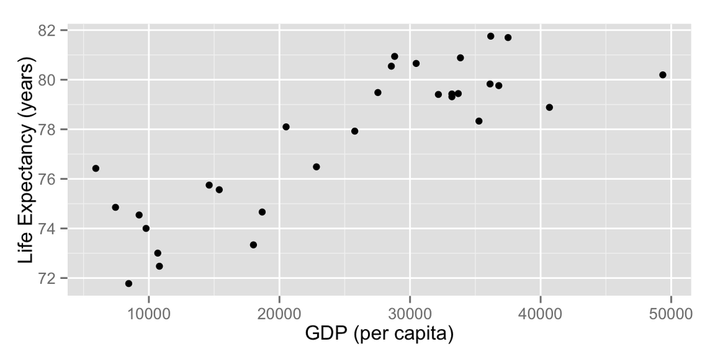

```r
gap_europe <- subset(gap_combined, continent == 'Europe' & year == 2007)

ggplot(gap_europe, aes(x=gdpPercap, y = lifeExp)) +
        geom_point() + xlab("GDP (per capita)") + ylab("Life Expectancy (years)")
```

Our “stretch goal” is easy to achieve by simply modifying our arguments to subset and making minor changes to the aesthetics (see `aes`) specified in the `ggplot` function.

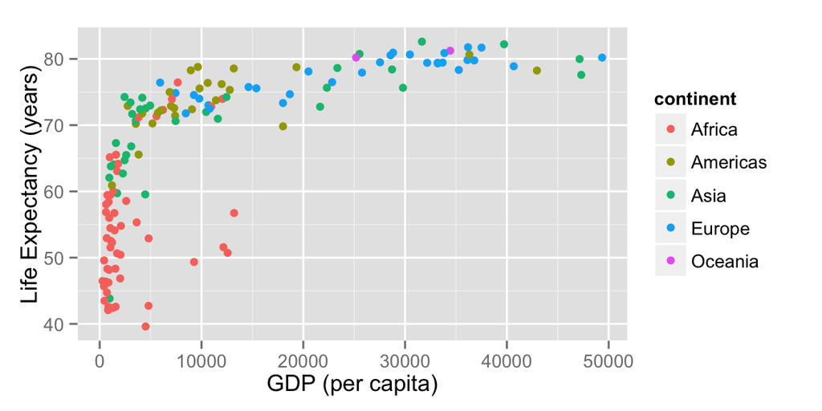

```r
gap_2007 <- subset(gap_combined, year == 2007)

ggplot(gap_2007, aes(x=gdpPercap, y = lifeExp, group=continent, color=continent)) +
        geom_point() + xlab("GDP (per capita)") + ylab("Life Expectancy (years)")
```